# Prosper Loans Dataset

## by Amr Gamal Anwar

## Investigation Overview

This investigation aims to visualize the features that affects the loan amount and thus to consider these features in our decision making process.

## Dataset Overview

The data set contains 113,937 values and 81 features, such as borrower interest rate, lLoan amount, and income. I have chosen 15 feature which I though would be of the most significance.

## What is the most popular loan term?

Each loan has a fixed term lenght, 12 months, 36 months, or 60 months. When investigating their counts, I found that the medium length term of 36 months is significantly more frequent than the other two terms.

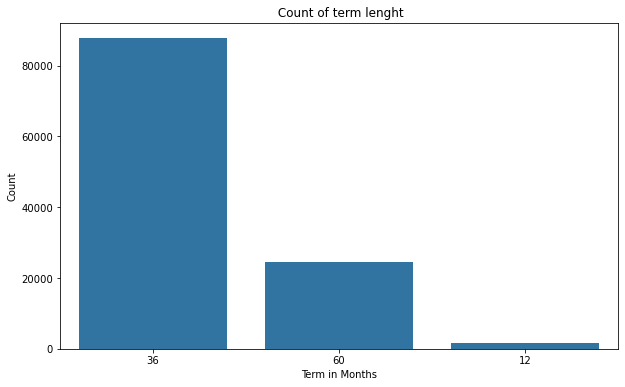

## Distribution of Estimated Return from Loans

Estimated return is the return we expect from giving out a loan. By looking at the distribution of this estimate, we find that the most points occur arround 0.07 and 0.08, with the distribution being a normal distribution.

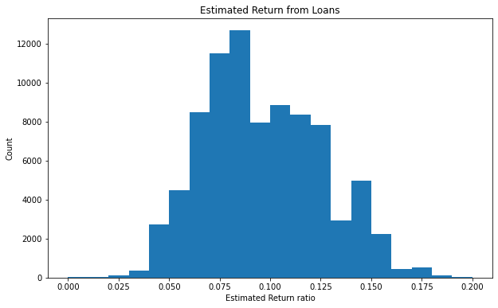

## How many borrowers do we have in each income range? and do they own a home?

When we look at a bivariate relation between the income range of borrowers and the fact they own a home or not, we observe that higher income ranges usually also own a home, while the opposite is true for lower income ranges.

Another observation is that the highest count of borrowers we have is borrowers from medium income ranges 25,000 to 49,999 dollars that do not own a home.

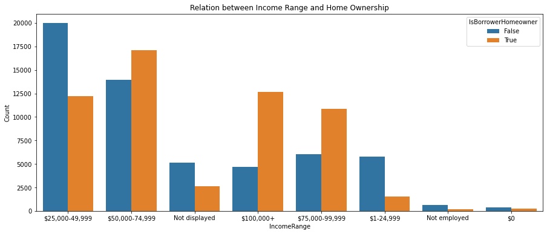

## How the income range of a borrower and the loan term affects the loan amount given?

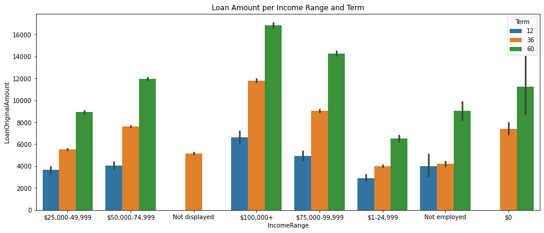